# Can Combining Histopathology and RNA-seq Improve Risk Stratification to Reduce Under-treatment in Breast Cancer?

DATA3888 Data Science Capstone, Biomed17

Guanyu Chen, Serafina Aurelia, Kush Dewan, Thinh Duong, Ni Putu Ananda Maheswari, Nael Panjaitan

2026-05-31

# 1 Executive Summary

**Background.** Breast cancer treatment decisions in early-stage disease rely on histopathological markers that, while clinically essential, do not fully reflect the molecular heterogeneity of the tumour. Patients whose RNA-seq profile diverges from their histopathological assessment may receive treatment that is mismatched to their underlying biology, with measurable consequences for survival.

**Methods.** Using the SCAN-B GSE96058 cohort restricted to ER-positive, endocrine-treated patients (n = 2,512), four survival models were compared under a single nested cross-validation framework (5 repeats by 5 outer folds, 25 fits each): Cox proportional hazards with LASSO regularisation in two configurations (gene expression only, and gene expression plus six histopathological variables), and the analogous pair of Random Survival Forest models. Discrimination was measured by Harrell’s C-statistic, with paired t-tests comparing within each model family across identical folds.

**Key Findings.** The combined Cox model achieved the highest mean C-statistic (0.766, SD 0.036), significantly outperforming the gene-only Cox model (0.695, SD 0.044, paired t-test p < 0.0001). The same pattern held for Random Survival Forest (combined: 0.716, gene-only: 0.674, paired p < 0.0001), but the parametric Cox approach exceeded the non-parametric forest at both configurations. Stability selection identified 11 genes consistently retained by the combined Cox model, and the final refit stratified patients into three risk tiers with sharply separated observed mortality (Low 1.2%, Medium 4.9%, High 20.2%).

**Conclusion.** Combining histopathology with RNA-seq materially improves survival risk stratification in ER+ endocrine-treated breast cancer. The resulting model is operationalised via a Shiny application that returns a personalised risk tier and per-feature drivers for clinician review.

# 2 Introduction

Breast cancer is the most common malignancy among women worldwide and a leading cause of cancer-related mortality, with more than two million new diagnoses each year (Sung et al., 2021). Treatment decisions for early-stage hormone-receptor-positive disease are guided primarily by histopathological and clinicopathological indicators: tumour grade, estrogen and progesterone receptor (ER/PgR) status, HER2 status, Ki67, tumour size, and nodal involvement. These markers are central to current clinical practice but do not fully capture the molecular heterogeneity of breast cancer, leaving open the question of whether some patients are systematically under-treated relative to their underlying risk.

RNA sequencing offers a complementary view of tumour biology by measuring genome-wide gene expression (Kukurba and Montgomery, 2015). Brueffer et al. (2018) demonstrated that RNA-seq based multigene classifiers can approach the accuracy of conventional histopathology for biomarker assessment and improve prognostic stratification in hormone-responsive subtypes. Despite this evidence, a translational gap persists: identifying discordance between molecular and histopathological signal is one task, and turning that signal into a decision-support output that practising clinicians can act on is another.

## 2.1 Research Question

This project addresses the following question:

> *Does combining histopathology with RNA-seq expression data improve survival risk stratification in ER-positive, endocrine-treated breast cancer, and can the resulting risk score be translated into clinically actionable tiers?*

Three concrete sub-aims follow. First, evaluate whether two distinct modelling families, Cox proportional hazards with LASSO and Random Survival Forest, give consistent answers about the marginal value of histopathological variables on top of gene expression. Second, identify a small, stable gene panel that can be elicited from a single CSV upload in a deployable tool. Third, translate the resulting continuous risk score into a three-tier output (Low, Medium, High) that maps onto a clinical reassessment decision.

# 3 Background

## 3.1 Dataset

All analyses use GSE96058 from the SCAN-B (Sweden Cancerome Analysis Network, Breast) study, a population-based cohort of breast tumours profiled by RNA sequencing with linked clinical and histopathological records. The full cohort comprises six expression sub-matrices plus a replicate set. After removing replicates and excluding patients with missing ER status, the working cohort contains 2,512 ER-positive, endocrine-treated patients with overall survival follow-up (`ovrallSurvDays`, `ovrallSurvEvent`). Six routine histopathological and clinicopathological variables are used: NHG grade, PgR status, HER2 status, tumour size, age at diagnosis, and lymph node status. Ki67 was excluded due to a 54.8% missingness rate.

## 3.2 Motivating Evidence

The clinical motivation for combining RNA-seq with histopathology comes from a signal in the SCAN-B data itself. When the molecular ER classifier (er_MGC) disagrees with the histopathological ER call, specifically MGC-negative but Hist-positive (denoted “FN”), overall survival is markedly worse than for fully concordant ER-positive (TP) patients (Figure 1, log-rank p = 0.0017). This indicates that the histopathological label alone misses a clinically meaningful subgroup whose biology is captured by gene expression, providing the empirical justification for the modelling approach that follows.

```r
library(GSE96058)
library(tidyverse)
library(survival)
library(survminer)
library(glmnet)
library(limma)
library(survcomp)
library(randomForestSRC)
library(ggplot2)
library(knitr)
```

```r
for (OBJ in data(package = "GSE96058")$results[, "Item"])
  assign(sub("GSE96058_", "", OBJ), get(OBJ))

detach(package:GSE96058, unload = TRUE)

full_expression <- cbind(
  geneExpression_sub1,
  geneExpression_sub2,
  geneExpression_sub3,
  geneExpression_sub4,
  geneExpression_sub5,
  geneExpression_repl1
)

df_full <- sampDesc %>%
  filter(isRepl == FALSE,
         er_Status != "NA")

df_erpos_endo <- df_full %>%
  filter(er_Status == 1,
         endocrine_treated == 1) %>%
  mutate(
    lymphNode_binary = case_when(
      lymphNode_Status == "NodeNegative" ~ 0,
      lymphNode_Status == "NodePositive" ~ 1,
      TRUE ~ NA_real_
    ),
    lymphNode_binary = ifelse(is.na(lymphNode_binary), 0, lymphNode_binary),
    pgr_Status       = ifelse(is.na(pgr_Status),  1, pgr_Status),
    her2_Status      = ifelse(is.na(her2_Status),  0, her2_Status),
    tumor_size       = ifelse(is.na(tumor_size),
                              median(tumor_size, na.rm = TRUE), tumor_size),
    ovrallSurvEvent  = as.numeric(ovrallSurvEvent)
  )


expr_endo <- full_expression[,
               colnames(full_expression) %in% df_erpos_endo$title,
               drop = FALSE]

df_erpos_endo <- df_erpos_endo[
  match(colnames(expr_endo), df_erpos_endo$title), ]
stopifnot(identical(colnames(expr_endo), df_erpos_endo$title))

saveRDS(df_erpos_endo, "./models/df_erpos_endo.rds")
saveRDS(expr_endo,     "./models/expr_endo.rds")
```

```r
df_eda <- df_full %>%
  mutate(er_concordance = case_when(
    er_MGC == 0 & er_Status == 0 ~ "TN",
    er_MGC == 1 & er_Status == 1 ~ "TP",
    er_MGC == 0 & er_Status == 1 ~ "FN",
    er_MGC == 1 & er_Status == 0 ~ "FP",
    TRUE ~ NA_character_
  ))

df_conc <- df_eda %>%
  filter(er_concordance %in% c("FN", "TP")) %>%
  mutate(ovrallSurvEvent = as.numeric(ovrallSurvEvent))
```

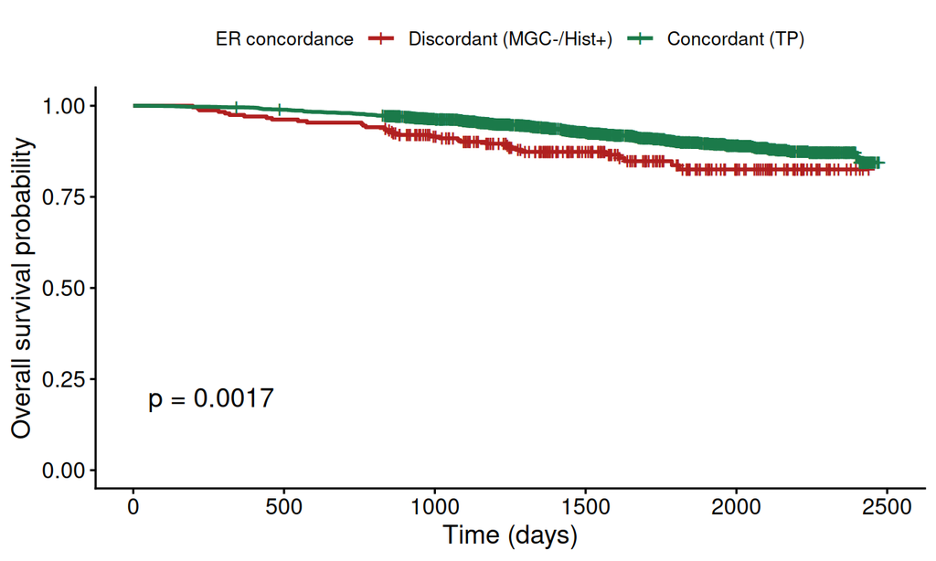

Figure 1. Kaplan-Meier overall survival in the SCAN-B cohort, comparing fully concordant ER-positive (TP) patients to MGC-negative / Hist-positive discordant (FN) patients. The log-rank test gives p = 0.0017, indicating that the discordant subgroup has significantly worse survival than the fully concordant group. This is the empirical motivation for combining RNA-seq with histopathology.

```r
surv_fit_eda <- survfit(Surv(ovrallSurvDays, ovrallSurvEvent) ~ er_concordance,
                        data = df_conc)
ggsurvplot(
  surv_fit_eda, data = df_conc, pval = TRUE,
  legend.title = "ER concordance",
  legend.labs  = c("Discordant (MGC-/Hist+)", "Concordant (TP)"),
  palette      = c("#B02020", "#1B7A4A"),
  xlab         = "Time (days)",
  ylab         = "Overall survival probability",
  risk.table   = FALSE
)
```

# 4 Methods

## 4.1 Workflow Overview

Figure 2 summarises the end-to-end pipeline: cohort selection from GSE96058, nested cross-validation across Cox-LASSO and Random Survival Forest (each in gene-only and combined configurations), aggregation of C-statistics, final refit with tertile cutoffs, and deployment as a risk analysis tool. Yellow boxes denote data steps, blue boxes compute steps, and green the final deliverable.

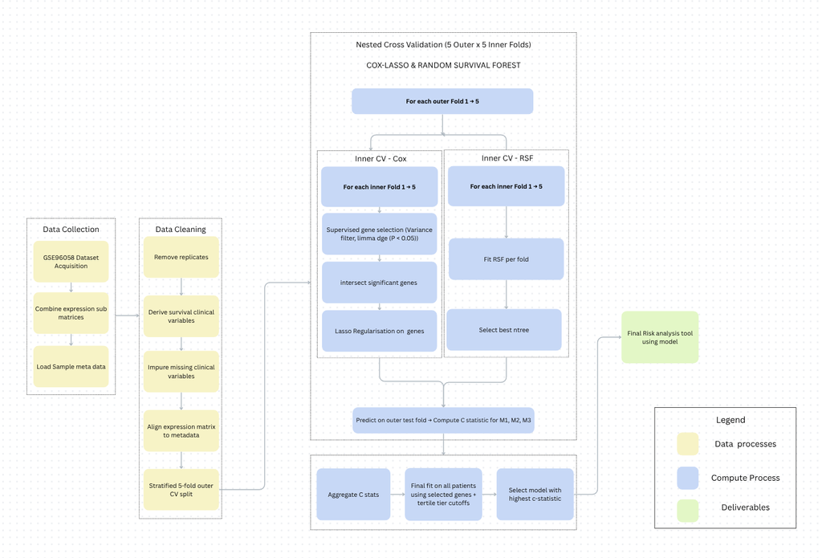

Figure 2. Analysis workflow for Cox-LASSO and Random Survival Forest model development. Yellow = data processes, blue = compute processes, green = deliverables. The nested cross-validation block (5 outer x 5 inner folds) evaluates both model families in parallel before the highest-performing configuration is selected for the final risk analysis tool.

```r
knitr::include_graphics("workflow_diagram.png")
```

## 4.2 Data Preprocessing

The six expression sub-matrices supplied with the GSE96058 R data package were concatenated into a single gene-by-sample expression matrix and aligned with the clinical metadata. Replicate samples were dropped, missing categorical clinical values were imputed by mode (lymph node negative for missing nodal status, PgR-positive and HER2-negative defaults for missing receptor calls), and tumour size was median-imputed. The cohort was then restricted to ER-positive patients on endocrine therapy. Overall survival was modelled in days with the associated event indicator; no other endpoints (e.g. disease-free survival) were considered in this analysis. The full data assembly code is shown in the `data-load` chunk earlier in the report.

## 4.3 Modelling Framework

Four candidate models were evaluated under a single nested cross-validation design, two from each modelling family:

- **Cox-Gene**: Cox proportional hazards with LASSO regularisation (`glmnet`, `family = "cox"`, `alpha = 1`), gene-expression features only.
- **Cox-Combined**: Cox proportional hazards with LASSO, gene expression plus six histopathological variables; clinical variables entered with `penalty.factor = 0` so they were always retained while gene coefficients were subject to L1 shrinkage.
- **RSF-Gene**: Random Survival Forest (`randomForestSRC::rfsrc`), gene-expression features only.
- **RSF-Combined**: Random Survival Forest with the six histopathological variables added.

Cox-LASSO and Random Survival Forest sit at opposite ends of the bias-variance trade-off for survival data. Cox-LASSO is semi-parametric, assumes proportional hazards, and yields interpretable per-feature coefficients suitable for clinical deployment (Friedman et al., 2010). RSF is non-parametric, makes no proportional-hazards assumption, and captures non-linearities and interactions automatically (Ishwaran et al., 2008). Running both families across the same outer folds lets us check whether the conclusion about the marginal value of histopathological variables is an artefact of one model class or a genuine signal in the data.

## 4.4 Nested Cross-Validation

All four models share the same 5 repeats by 5-fold outer cross-validation (25 outer fits), stratified on event status, with an inner 5-fold loop used for feature selection and hyperparameter tuning. For each outer fold, approximately 2,010 patients form the outer training set and 502 form the held-out outer test set.

For Cox-LASSO, the inner CV is also used to select the regularisation parameter via `cv.glmnet` at `lambda.min`. For RSF, the inner CV selects `ntree` from {500, 1000}, with `nodesize` fixed at 15 and variable importance enabled on the outer fit. After the inner loop completes, limma is rerun on the full outer training set and the final outer-fold model is fit at the inner-CV-selected hyperparameter.

```r
var_thresh      <- 0.5
pval_thresh     <- 0.05
n_outer_repeats <- 5
n_outer_folds   <- 5
n_inner_folds   <- 5

histopath_vars <- c("nhg", "pgr_Status", "her2_Status",
                    "tumor_size", "ageAtDx", "lymphNode_binary")

make_stratified_folds <- function(y, nfolds, seed) {
  set.seed(seed)
  fold_id <- integer(length(y))
  for (cls in unique(y)) {
    idx <- which(y == cls)
    fold_id[idx] <- sample(rep(seq_len(nfolds), length.out = length(idx)))
  }
  fold_id
}

select_genes_limma <- function(expr_train, event_train,
                               var_thresh, pval_thresh) {
  gv     <- apply(expr_train, 1, var)
  keep_v <- rownames(expr_train)[gv > var_thresh]
  if (length(keep_v) < 2) return(character(0))
  expr_v <- expr_train[keep_v, , drop = FALSE]
  if (length(unique(event_train)) < 2) return(character(0))
  design <- model.matrix(~ event_train)
  fit    <- eBayes(lmFit(expr_v, design))
  tt     <- topTable(fit, coef = 2, number = Inf,
                     adjust.method = "BH", sort.by = "p")
  rownames(tt)[tt$adj.P.Val < pval_thresh]
}

n_outer_total <- n_outer_repeats * n_outer_folds

cox_rds_path <- "./models/cox_m2_m3_final.rds"
rsf_rds_path <- "./models/rsf_nested_cv.rds"

cox_cv_in_memory <- function() {
  exists("c_model2", inherits = FALSE) &&
    exists("c_model3", inherits = FALSE) &&
    length(c_model2) == n_outer_total &&
    any(!is.na(c_model2))
}

rsf_cv_in_memory <- function() {
  exists("c_rsf_genes", inherits = FALSE) &&
    exists("c_rsf_combined", inherits = FALSE) &&
    length(c_rsf_genes) == n_outer_total &&
    any(!is.na(c_rsf_genes))
}
```

```r
compute_c <- function(lp, surv_time, surv_event) {
  tryCatch(
    concordance.index(
      x          = lp,
      surv.time  = surv_time,
      surv.event = surv_event,
      method     = "noether"
    )$c.index,
    error = function(e) NA_real_
  )
}

cox_results_ready <- cox_cv_in_memory()

if (!cox_results_ready && file.exists(cox_rds_path)) {
  saved <- readRDS(cox_rds_path)
  c_model2            <- saved$c_model2
  c_model3            <- saved$c_model3
  fold_summary_cox    <- saved$fold_summary
  selection_counts_m2 <- saved$selection_counts_m2
  selection_counts_m3 <- saved$selection_counts_m3
  coef_sums_m2        <- saved$coef_sums_m2
  coef_sums_m3        <- saved$coef_sums_m3
  cox_results_ready   <- TRUE
  cat("Cox nested-CV results loaded from", cox_rds_path, "\n")
} else if (cox_results_ready) {
  cat("Cox nested-CV results already in memory; skipping recompute.\n")
}
```

```r
if (!cox_results_ready) {
  c_model2 <- numeric(n_outer_total)
  c_model3 <- numeric(n_outer_total)

  fold_log <- vector("list", n_outer_total)
  fit_i    <- 0L

  selection_counts_m2 <- integer(0)
  coef_sums_m2        <- numeric(0)
  selection_counts_m3 <- integer(0)
  coef_sums_m3        <- numeric(0)
}
```

```r
# Cox nested CV.
# Internal naming uses model2 (gene only) and model3 (combined), as in
# the original cox_models.Rmd; in the report these are referred to as
# Cox-Gene and Cox-Combined respectively.
# Skips the loop when results are already in memory or in cox_rds_path.

if (cox_results_ready) {
  cat("Skipping Cox nested-CV loop (using saved results).\n")
} else {

for (rep_i in seq_len(n_outer_repeats)) {

  cat("=== Repeat", rep_i, "===\n")

  outer_folds <- make_stratified_folds(
    df_erpos_endo$ovrallSurvEvent,
    n_outer_folds,
    seed = 2000 + rep_i
  )

  for (k in seq_len(n_outer_folds)) {

    fit_i  <- fit_i + 1L
    tr_idx <- which(outer_folds != k)
    te_idx <- which(outer_folds == k)

    train_df   <- df_erpos_endo[tr_idx, ]
    test_df    <- df_erpos_endo[te_idx, ]
    train_surv <- Surv(train_df$ovrallSurvDays, train_df$ovrallSurvEvent)
    expr_tr    <- expr_endo[, tr_idx, drop = FALSE]
    expr_te    <- expr_endo[, te_idx, drop = FALSE]

    cat("  Fold", k,
        "| train:", length(tr_idx),
        "| test:",  length(te_idx), "\n")

    inner_folds <- make_stratified_folds(
      train_df$ovrallSurvEvent,
      n_inner_folds,
      seed = 5000 + 100 * rep_i + k
    )

    candidate_genes_inner <- vector("list", n_inner_folds)

    for (ik in seq_len(n_inner_folds)) {
      itr_idx   <- which(inner_folds != ik)
      expr_itr  <- expr_tr[, itr_idx, drop = FALSE]
      event_itr <- train_df$ovrallSurvEvent[itr_idx]
      candidate_genes_inner[[ik]] <- select_genes_limma(
        expr_itr, event_itr, var_thresh, pval_thresh
      )
    }

    union_genes <- unique(unlist(candidate_genes_inner))
    union_genes <- union_genes[nchar(union_genes) > 0]

    cat("    Inner union genes:", length(union_genes), "\n")

    if (length(union_genes) < 2) {
      cat("    Too few genes, skipping M2 and M3\n")
      c_model2[fit_i] <- NA_real_
      c_model3[fit_i] <- NA_real_
      next
    }

    x_tr_inner <- t(expr_tr[union_genes, , drop = FALSE])

    cv_inner <- cv.glmnet(
      x        = x_tr_inner,
      y        = train_surv,
      family   = "cox",
      alpha    = 1,
      foldid   = inner_folds,
      cox.ties = "breslow"
    )

    best_lambda_m2 <- cv_inner$lambda.min
    best_lambda_m3 <- cv_inner$lambda.min

    outer_genes <- select_genes_limma(
      expr_tr, train_df$ovrallSurvEvent,
      var_thresh, pval_thresh
    )

    cat("    Outer DGE genes:", length(outer_genes), "\n")

    if (length(outer_genes) < 2) {
      cat("    Too few outer genes, skipping\n")
      c_model2[fit_i] <- NA_real_
      c_model3[fit_i] <- NA_real_
      next
    }

    x_tr_outer <- t(expr_tr[outer_genes, , drop = FALSE])
    x_te_outer <- t(expr_te[outer_genes, , drop = FALSE])

    final_m2 <- glmnet(
      x        = x_tr_outer,
      y        = train_surv,
      family   = "cox",
      alpha    = 1,
      lambda   = best_lambda_m2,
      cox.ties = "breslow"
    )

    cox2_pred <- as.vector(
      predict(final_m2, newx = x_te_outer,
              s = best_lambda_m2, type = "link")
    )

    c2 <- compute_c(cox2_pred,
                    test_df$ovrallSurvDays,
                    test_df$ovrallSurvEvent)

    cc2      <- coef(final_m2, s = best_lambda_m2)
    cc2_vals <- setNames(as.numeric(cc2), rownames(cc2))
    nz2      <- names(cc2_vals)[cc2_vals != 0]

    cat("    M2 genes:", length(nz2),
        "| lambda:", round(best_lambda_m2, 4),
        "| C:", round(c2, 3), "\n")

    for (g in nz2) {
      prev_n <- if (g %in% names(selection_counts_m2)) selection_counts_m2[[g]] else 0L
      prev_c <- if (g %in% names(coef_sums_m2))        coef_sums_m2[[g]]        else 0
      selection_counts_m2[g] <- prev_n + 1L
      coef_sums_m2[g]        <- prev_c + cc2_vals[g]
    }

    train_hist_mat <- model.matrix(
      ~ nhg + pgr_Status + her2_Status +
        tumor_size + ageAtDx + lymphNode_binary - 1,
      data = train_df
    )
    test_hist_mat <- model.matrix(
      ~ nhg + pgr_Status + her2_Status +
        tumor_size + ageAtDx + lymphNode_binary - 1,
      data = test_df
    )

    common_cols    <- intersect(colnames(train_hist_mat),
                                colnames(test_hist_mat))
    train_hist_mat <- train_hist_mat[, common_cols, drop = FALSE]
    test_hist_mat  <- test_hist_mat[,  common_cols, drop = FALSE]
    n_hist_cols    <- ncol(train_hist_mat)

    x_tr_outer_m3 <- cbind(train_hist_mat, x_tr_outer)
    x_te_outer_m3 <- cbind(test_hist_mat,  x_te_outer)
    pen_outer_m3  <- c(rep(0, n_hist_cols),
                       rep(1, length(outer_genes)))

    final_m3 <- glmnet(
      x              = x_tr_outer_m3,
      y              = train_surv,
      family         = "cox",
      alpha          = 1,
      lambda         = best_lambda_m3,
      penalty.factor = pen_outer_m3,
      cox.ties       = "breslow"
    )

    cox3_pred <- as.vector(
      predict(final_m3, newx = x_te_outer_m3,
              s = best_lambda_m3, type = "link")
    )

    c3 <- compute_c(cox3_pred,
                    test_df$ovrallSurvDays,
                    test_df$ovrallSurvEvent)

    cc3       <- coef(final_m3, s = best_lambda_m3)
    cc3_vals  <- setNames(as.numeric(cc3), rownames(cc3))
    nz3_genes <- names(cc3_vals)[cc3_vals != 0 &
                                   names(cc3_vals) %in% outer_genes]

    cat("    M3 genes:", length(nz3_genes),
        "| lambda:", round(best_lambda_m3, 4),
        "| C:", round(c3, 3), "\n")

    for (g in nz3_genes) {
      prev_n <- if (g %in% names(selection_counts_m3)) selection_counts_m3[[g]] else 0L
      prev_c <- if (g %in% names(coef_sums_m3))        coef_sums_m3[[g]]        else 0
      selection_counts_m3[g] <- prev_n + 1L
      coef_sums_m3[g]        <- prev_c + cc3_vals[g]
    }

    c_model2[fit_i] <- c2
    c_model3[fit_i] <- c3

    fold_log[[fit_i]] <- list(
      rep        = rep_i,
      fold       = k,
      n_union    = length(union_genes),
      n_outer    = length(outer_genes),
      n_lasso_m2 = length(nz2),
      n_lasso_m3 = length(nz3_genes),
      c_model2   = c2,
      c_model3   = c3
    )
  }
}

fold_summary_cox <- do.call(rbind, lapply(fold_log, as.data.frame))

saveRDS(
  list(
    c_model2            = c_model2,
    c_model3            = c_model3,
    fold_summary        = fold_summary_cox,
    selection_counts_m2 = selection_counts_m2,
    selection_counts_m3 = selection_counts_m3,
    coef_sums_m2        = coef_sums_m2,
    coef_sums_m3        = coef_sums_m3
  ),
  cox_rds_path
)

cox_results_ready <- TRUE
cat("Cox nested-CV complete; saved to", cox_rds_path, "\n")

}
```

```r
compute_c <- function(lp, surv_time, surv_event) {
  ok <- !is.na(lp) & !is.na(surv_time) & !is.na(surv_event)
  lp <- lp[ok]; surv_time <- surv_time[ok]; surv_event <- surv_event[ok]
  if (length(lp) < 2 || length(unique(lp)) < 2) return(NA_real_)
  tryCatch({
    cfit <- concordance(Surv(surv_time, surv_event) ~ lp, reverse = TRUE)
    cfit$concordance
  }, error = function(e) {
    cat("      [compute_c] error:", conditionMessage(e), "\n")
    NA_real_
  })
}

rsf_results_ready <- rsf_cv_in_memory()

if (!rsf_results_ready && file.exists(rsf_rds_path)) {
  saved <- readRDS(rsf_rds_path)
  c_rsf_genes          <- saved$c_rsf_genes
  c_rsf_combined       <- saved$c_rsf_combined
  fold_summary_rsf     <- saved$fold_summary
  vimp_counts_genes    <- saved$vimp_counts_genes
  vimp_counts_combined <- saved$vimp_counts_combined
  vimp_sums_genes      <- saved$vimp_sums_genes
  vimp_sums_combined   <- saved$vimp_sums_combined
  rsf_results_ready    <- TRUE
  cat("RSF nested-CV results loaded from", rsf_rds_path, "\n")
} else if (rsf_results_ready) {
  cat("RSF nested-CV results already in memory; skipping recompute.\n")
}
```

```r
if (!rsf_results_ready) {
  c_rsf_genes    <- numeric(n_outer_total)
  c_rsf_combined <- numeric(n_outer_total)

  fold_log <- vector("list", n_outer_total)
  fit_i    <- 0L

  vimp_counts_genes    <- integer(0)
  vimp_sums_genes      <- numeric(0)
  vimp_counts_combined <- integer(0)
  vimp_sums_combined   <- numeric(0)
}
```

```r
# Random Survival Forest nested CV.
# RSF-Gene uses gene-expression features only; RSF-Combined adds the
# six histopathological variables. Inner CV picks ntree from {500, 1000}.
# Skips the loop when results are already in memory or in rsf_rds_path.

if (rsf_results_ready) {
  cat("Skipping RSF nested-CV loop (using saved results).\n")
} else {

for (rep_i in seq_len(n_outer_repeats)) {

  cat("=== Repeat", rep_i, "===\n")

  outer_folds <- make_stratified_folds(
    df_erpos_endo$ovrallSurvEvent,
    n_outer_folds,
    seed = 2000 + rep_i
  )

  for (k in seq_len(n_outer_folds)) {

    fit_i  <- fit_i + 1L
    tr_idx <- which(outer_folds != k)
    te_idx <- which(outer_folds == k)

    train_df   <- df_erpos_endo[tr_idx, ]
    test_df    <- df_erpos_endo[te_idx, ]
    expr_tr    <- expr_endo[, tr_idx, drop = FALSE]
    expr_te    <- expr_endo[, te_idx, drop = FALSE]

    cat("  Fold", k,
        "| train:", length(tr_idx),
        "| test:",  length(te_idx), "\n")

    inner_folds <- make_stratified_folds(
      train_df$ovrallSurvEvent,
      n_inner_folds,
      seed = 5000 + 100 * rep_i + k
    )

    candidate_genes_inner <- vector("list", n_inner_folds)

    for (ik in seq_len(n_inner_folds)) {
      itr_idx   <- which(inner_folds != ik)
      expr_itr  <- expr_tr[, itr_idx, drop = FALSE]
      event_itr <- train_df$ovrallSurvEvent[itr_idx]
      candidate_genes_inner[[ik]] <- select_genes_limma(
        expr_itr, event_itr, var_thresh, pval_thresh
      )
    }

    union_genes <- unique(unlist(candidate_genes_inner))
    union_genes <- union_genes[nchar(union_genes) > 0]

    cat("    Inner union genes:", length(union_genes), "\n")

    if (length(union_genes) < 2) {
      cat("    Too few genes, skipping RSF models\n")
      c_rsf_genes[fit_i]    <- NA_real_
      c_rsf_combined[fit_i] <- NA_real_
      next
    }

    ntree_candidates <- c(500, 1000)
    inner_c_by_ntree <- numeric(length(ntree_candidates))

    for (nt_i in seq_along(ntree_candidates)) {
      nt <- ntree_candidates[nt_i]
      inner_c_vals <- numeric(n_inner_folds)

      for (ik in seq_len(n_inner_folds)) {
        itr_idx <- which(inner_folds != ik)
        ite_idx <- which(inner_folds == ik)

        x_itr <- as.data.frame(t(expr_tr[union_genes, itr_idx, drop = FALSE]))
        x_itr[] <- lapply(x_itr, as.numeric)
        x_itr$time  <- train_df$ovrallSurvDays[itr_idx]
        x_itr$event <- train_df$ovrallSurvEvent[itr_idx]

        x_ite <- as.data.frame(t(expr_tr[union_genes, ite_idx, drop = FALSE]))
        x_ite[] <- lapply(x_ite, as.numeric)

        rsf_inner <- rfsrc(
          Surv(time, event) ~ .,
          data       = x_itr,
          ntree      = nt,
          nodesize   = 15,
          importance = FALSE,
          seed       = 42
        )

        pred_inner <- predict(rsf_inner, newdata = x_ite)
        inner_c_vals[ik] <- compute_c(
          pred_inner$predicted,
          train_df$ovrallSurvDays[ite_idx],
          train_df$ovrallSurvEvent[ite_idx]
        )
      }
      inner_c_by_ntree[nt_i] <- mean(inner_c_vals, na.rm = TRUE)
    }

    best_ntree <- ntree_candidates[which.max(inner_c_by_ntree)]
    cat("    Best ntree:", best_ntree, "\n")

    outer_genes <- select_genes_limma(
      expr_tr, train_df$ovrallSurvEvent,
      var_thresh, pval_thresh
    )

    cat("    Outer DGE genes:", length(outer_genes), "\n")

    if (length(outer_genes) < 2) {
      cat("    Too few outer genes, skipping\n")
      c_rsf_genes[fit_i]    <- NA_real_
      c_rsf_combined[fit_i] <- NA_real_
      next
    }

    x_tr_genes <- as.data.frame(t(expr_tr[outer_genes, , drop = FALSE]))
    x_tr_genes[] <- lapply(x_tr_genes, as.numeric)
    x_tr_genes$time  <- train_df$ovrallSurvDays
    x_tr_genes$event <- train_df$ovrallSurvEvent

    x_te_genes <- as.data.frame(t(expr_te[outer_genes, , drop = FALSE]))
    x_te_genes[] <- lapply(x_te_genes, as.numeric)

    rsf_genes <- rfsrc(
      Surv(time, event) ~ .,
      data       = x_tr_genes,
      ntree      = best_ntree,
      nodesize   = 15,
      importance = TRUE,
      seed       = 42
    )

    pred_genes <- predict(rsf_genes, newdata = x_te_genes)

    c_g <- compute_c(
      pred_genes$predicted,
      test_df$ovrallSurvDays,
      test_df$ovrallSurvEvent
    )

    vimp_g <- rsf_genes$importance
    top_genes_g <- names(sort(vimp_g[vimp_g > 0], decreasing = TRUE))

    cat("    RSF-Genes top features:", min(length(top_genes_g), 10),
        "| ntree:", best_ntree,
        "| C:", round(c_g, 3), "\n")

    for (g in top_genes_g) {
      prev_n <- if (g %in% names(vimp_counts_genes)) vimp_counts_genes[[g]] else 0L
      prev_c <- if (g %in% names(vimp_sums_genes))   vimp_sums_genes[[g]]   else 0
      vimp_counts_genes[g] <- prev_n + 1L
      vimp_sums_genes[g]   <- prev_c + vimp_g[g]
    }

    nhg_levels <- levels(as.factor(df_erpos_endo$nhg))

    x_tr_combined <- as.data.frame(t(expr_tr[outer_genes, , drop = FALSE]))
    x_tr_combined[] <- lapply(x_tr_combined, as.numeric)
    x_tr_combined$nhg              <- as.numeric(factor(train_df$nhg, levels = nhg_levels))
    x_tr_combined$pgr_Status       <- suppressWarnings(as.numeric(as.character(train_df$pgr_Status)))
    x_tr_combined$her2_Status      <- suppressWarnings(as.numeric(as.character(train_df$her2_Status)))
    x_tr_combined$tumor_size       <- as.numeric(train_df$tumor_size)
    x_tr_combined$ageAtDx          <- as.numeric(train_df$ageAtDx)
    x_tr_combined$lymphNode_binary <- as.numeric(train_df$lymphNode_binary)
    x_tr_combined$pgr_Status[is.na(x_tr_combined$pgr_Status)]   <- 1
    x_tr_combined$her2_Status[is.na(x_tr_combined$her2_Status)] <- 0
    x_tr_combined$time             <- train_df$ovrallSurvDays
    x_tr_combined$event            <- train_df$ovrallSurvEvent

    x_te_combined <- as.data.frame(t(expr_te[outer_genes, , drop = FALSE]))
    x_te_combined[] <- lapply(x_te_combined, as.numeric)
    x_te_combined$nhg              <- as.numeric(factor(test_df$nhg, levels = nhg_levels))
    x_te_combined$pgr_Status       <- suppressWarnings(as.numeric(as.character(test_df$pgr_Status)))
    x_te_combined$her2_Status      <- suppressWarnings(as.numeric(as.character(test_df$her2_Status)))
    x_te_combined$tumor_size       <- as.numeric(test_df$tumor_size)
    x_te_combined$ageAtDx          <- as.numeric(test_df$ageAtDx)
    x_te_combined$lymphNode_binary <- as.numeric(test_df$lymphNode_binary)
    x_te_combined$pgr_Status[is.na(x_te_combined$pgr_Status)]   <- 1
    x_te_combined$her2_Status[is.na(x_te_combined$her2_Status)] <- 0

    rsf_combined <- rfsrc(
      Surv(time, event) ~ .,
      data       = x_tr_combined,
      ntree      = best_ntree,
      nodesize   = 15,
      importance = TRUE,
      seed       = 42
    )

    pred_combined <- tryCatch(
      predict(rsf_combined, newdata = x_te_combined),
      error = function(e) {
        cat("      [predict RSF-combined] error:", conditionMessage(e), "\n")
        NULL
      }
    )

    if (is.null(pred_combined)) {
      c_rsf_combined[fit_i] <- NA_real_
      cat("    RSF-Combined: predict failed, skipping\n")
    } else {
      cat("      [debug] pred range:", range(pred_combined$predicted, na.rm = TRUE),
          "| NAs:", sum(is.na(pred_combined$predicted)), "\n")
    }

    c_c <- if (!is.null(pred_combined)) {
      compute_c(
        pred_combined$predicted,
        test_df$ovrallSurvDays,
        test_df$ovrallSurvEvent
      )
    } else {
      NA_real_
    }

    vimp_c <- rsf_combined$importance
    top_features_c <- names(sort(vimp_c[vimp_c > 0], decreasing = TRUE))

    cat("    RSF-Combined top features:", min(length(top_features_c), 10),
        "| ntree:", best_ntree,
        "| C:", round(c_c, 3), "\n")

    for (g in top_features_c) {
      prev_n <- if (g %in% names(vimp_counts_combined)) vimp_counts_combined[[g]] else 0L
      prev_c <- if (g %in% names(vimp_sums_combined))   vimp_sums_combined[[g]]   else 0
      vimp_counts_combined[g] <- prev_n + 1L
      vimp_sums_combined[g]   <- prev_c + vimp_c[g]
    }

    c_rsf_genes[fit_i]    <- c_g
    c_rsf_combined[fit_i] <- c_c

    fold_log[[fit_i]] <- list(
      rep          = rep_i,
      fold         = k,
      n_union      = length(union_genes),
      n_outer      = length(outer_genes),
      best_ntree   = best_ntree,
      n_vimp_genes = length(top_genes_g),
      n_vimp_comb  = length(top_features_c),
      c_rsf_genes  = c_g,
      c_rsf_comb   = c_c
    )
  }
}

fold_summary_rsf <- do.call(rbind, lapply(fold_log, as.data.frame))

saveRDS(
  list(
    c_rsf_genes          = c_rsf_genes,
    c_rsf_combined       = c_rsf_combined,
    fold_summary         = fold_summary_rsf,
    vimp_counts_genes    = vimp_counts_genes,
    vimp_counts_combined = vimp_counts_combined,
    vimp_sums_genes      = vimp_sums_genes,
    vimp_sums_combined   = vimp_sums_combined
  ),
  rsf_rds_path
)

rsf_results_ready <- TRUE
cat("RSF nested-CV complete; saved to", rsf_rds_path, "\n")

}
```

## 4.5 Evaluation Strategy

The primary discrimination metric is Harrell’s C-statistic (Harrell et al., 1982), defined as the proportion of evaluable patient pairs in which the model correctly ranks the patient who died first as having a higher predicted risk score; 0.5 represents no discrimination beyond chance, 1.0 represents perfect discrimination. The C-statistic is the natural choice for Cox models because it evaluates what the model is optimising (ranking by hazard) rather than imposing an arbitrary classification threshold (Steyerberg et al., 2010). For Cox we compute it via `survcomp::concordance.index` (Noether’s method); for RSF we use `survival::concordance` with `reverse = TRUE` on the raw predicted mortality, matching standard RSF practice.

Pairwise model comparison uses a paired t-test on the 25 per-fold C-statistics within each model family, pairing fold-by-fold so that both members of a comparison see identical patients in each split. Pairing is essential because within-fold correlation in performance is substantial, and an unpaired test would discard most of the statistical power available.

Stability selection follows Meinshausen and Buhlmann (2010): a gene is declared “stable” if it receives a non-zero LASSO coefficient (or, for RSF, a positive variable importance) in a sufficient fraction of the 25 outer fits. The default threshold is 80%; for the final deployed gene panel, this is relaxed to 70% on the Cox-Combined results to balance parsimony with stability, as discussed in the Stable Gene Panel results below.

# 5 Results

## 5.1 Cross-Validated Discrimination

Figure 3 presents the per-fold C-statistic across all 25 outer fits for the four models. Two findings are immediate. First, combining histopathology with gene expression improves discrimination in both modelling families: Cox-Combined exceeds Cox-Gene at nearly every fold, and RSF-Combined exceeds RSF-Gene at nearly every fold. Second, Cox-LASSO outperforms RSF at the matching configuration: Cox-Gene exceeds RSF-Gene, and Cox-Combined exceeds RSF-Combined.

```r
cox_ok <- cox_cv_in_memory()
rsf_ok <- rsf_cv_in_memory()

if (cox_ok && rsf_ok) {
  cox_saved <- list(
    c_model2       = c_model2,
    c_model3       = c_model3,
    fold_summary   = if (exists("fold_summary_cox", inherits = FALSE)) {
      fold_summary_cox
    } else {
      NULL
    }
  )
  rsf_saved <- list(
    c_rsf_genes    = c_rsf_genes,
    c_rsf_combined = c_rsf_combined,
    fold_summary   = if (exists("fold_summary_rsf", inherits = FALSE)) {
      fold_summary_rsf
    } else {
      NULL
    }
  )
  cv_available <- TRUE
} else if (file.exists(cox_rds_path) && file.exists(rsf_rds_path)) {
  cox_saved <- readRDS(cox_rds_path)
  rsf_saved <- readRDS(rsf_rds_path)
  cv_available <- TRUE
} else {
  cox_saved <- NULL
  rsf_saved <- NULL
  cv_available <- FALSE
}
```

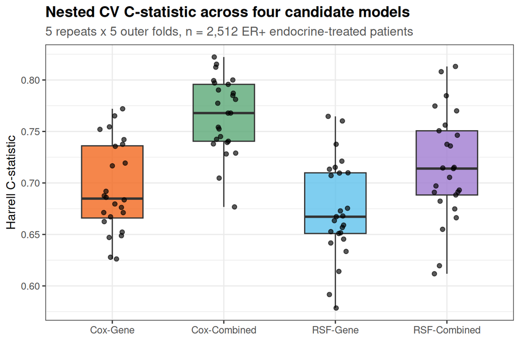

Figure 3. Per-fold Harrell C-statistic across 25 outer fits for the four candidate models (Cox-Gene, Cox-Combined, RSF-Gene, RSF-Combined). Both modelling families show a consistent gain from adding histopathological variables, and Cox-LASSO outperforms RSF at each matching configuration.

```r
if (!cv_available) {
  cat("Nested-CV results not yet available.\n",
      "Run the 'cox-loop' and 'rsf-loop' chunks in the Methods section first.\n",
      sep = "")
} else {
  n_cox <- length(cox_saved$c_model2)
  n_rsf <- length(rsf_saved$c_rsf_genes)

  box_df <- data.frame(
    C_statistic = c(cox_saved$c_model2,
                    cox_saved$c_model3,
                    rsf_saved$c_rsf_genes,
                    rsf_saved$c_rsf_combined),
    Model = factor(
      c(rep("Cox-Gene",     n_cox),
        rep("Cox-Combined", n_cox),
        rep("RSF-Gene",     n_rsf),
        rep("RSF-Combined", n_rsf)),
      levels = c("Cox-Gene", "Cox-Combined", "RSF-Gene", "RSF-Combined")
    )
  )

  print(
    ggplot(box_df, aes(x = Model, y = C_statistic, fill = Model)) +
      geom_boxplot(alpha = 0.78, width = 0.55, outlier.shape = NA) +
      geom_jitter(width = 0.12, size = 1.7, alpha = 0.65) +
      scale_fill_manual(values = c(
        "Cox-Gene"     = "#F26419",
        "Cox-Combined" = "#57A773",
        "RSF-Gene"     = "#5BC0EB",
        "RSF-Combined" = "#9E78CF"
      )) +
      labs(
        title    = "Nested CV C-statistic across four candidate models",
        subtitle = "5 repeats x 5 outer folds, n = 2,512 ER+ endocrine-treated patients",
        x        = NULL,
        y        = "Harrell C-statistic"
      ) +
      theme_bw(base_size = 12) +
      theme(legend.position = "none",
            plot.title      = element_text(face = "bold"),
            plot.subtitle   = element_text(colour = "#555555"))
  )
}
```

Table 1 summarises central tendency and spread. The combined Cox model achieves a mean C-statistic of 0.766 (SD 0.036, range 0.677 to 0.822), 0.071 higher than its gene-only counterpart (mean 0.695, SD 0.044, paired t-test p < 0.0001). The combined RSF model achieves a mean C-statistic of 0.716 (SD 0.052), 0.041 higher than its gene-only counterpart (mean 0.674, SD 0.047, paired p < 0.0001). All four sit above 0.5, and the combined models sit in the range commonly described as moderate-to-good discrimination in prognostic modelling literature (Hosmer and Lemeshow, 2000).

```r
if (!cv_available) {
  cat("Table 1 will appear here once the nested-CV chunks (cox-loop, rsf-loop) have been run.\n")
} else {
  summary_tbl <- data.frame(
    Model    = c("Cox-Gene", "Cox-Combined",
                 "RSF-Gene", "RSF-Combined"),
    Family   = c("Cox PH + LASSO",
                 "Cox PH + LASSO (clinical unpenalised)",
                 "Random Survival Forest",
                 "Random Survival Forest"),
    Features = c("Gene expression only",
                 "Gene expression + 6 clinical",
                 "Gene expression only",
                 "Gene expression + 6 clinical"),
    `Mean C` = sprintf("%.3f", c(
      mean(cox_saved$c_model2,       na.rm = TRUE),
      mean(cox_saved$c_model3,       na.rm = TRUE),
      mean(rsf_saved$c_rsf_genes,    na.rm = TRUE),
      mean(rsf_saved$c_rsf_combined, na.rm = TRUE))),
    SD = sprintf("%.3f", c(
      sd(cox_saved$c_model2,         na.rm = TRUE),
      sd(cox_saved$c_model3,         na.rm = TRUE),
      sd(rsf_saved$c_rsf_genes,      na.rm = TRUE),
      sd(rsf_saved$c_rsf_combined,   na.rm = TRUE))),
    Range = c(
      sprintf("%.3f to %.3f", min(cox_saved$c_model2,       na.rm = TRUE),
                              max(cox_saved$c_model2,       na.rm = TRUE)),
      sprintf("%.3f to %.3f", min(cox_saved$c_model3,       na.rm = TRUE),
                              max(cox_saved$c_model3,       na.rm = TRUE)),
      sprintf("%.3f to %.3f", min(rsf_saved$c_rsf_genes,    na.rm = TRUE),
                              max(rsf_saved$c_rsf_genes,    na.rm = TRUE)),
      sprintf("%.3f to %.3f", min(rsf_saved$c_rsf_combined, na.rm = TRUE),
                              max(rsf_saved$c_rsf_combined, na.rm = TRUE))),
    check.names = FALSE
  )
  knitr::kable(
    summary_tbl,
    caption = "Table 1. Nested cross-validated C-statistic across the four candidate models (5 repeats x 5 outer folds = 25 fits each). Within-family paired t-tests give p < 0.0001 in both Cox-Combined vs Cox-Gene and RSF-Combined vs RSF-Gene.",
    align   = c("l", "l", "l", "r", "r", "r")
  )
}
```

Table 1. Nested cross-validated C-statistic across the four candidate models (5 repeats x 5 outer folds = 25 fits each). Within-family paired t-tests give p < 0.0001 in both Cox-Combined vs Cox-Gene and RSF-Combined vs RSF-Gene.

| Model | Family | Features | Mean C | SD | Range |
| --- | --- | --- | --- | --- | --- |
| Cox-Gene | Cox PH + LASSO | Gene expression only | 0.695 | 0.044 | 0.626 to 0.772 |
| Cox-Combined | Cox PH + LASSO (clinical unpenalised) | Gene expression + 6 clinical | 0.766 | 0.036 | 0.677 to 0.822 |
| RSF-Gene | Random Survival Forest | Gene expression only | 0.674 | 0.047 | 0.579 to 0.765 |
| RSF-Combined | Random Survival Forest | Gene expression + 6 clinical | 0.716 | 0.052 | 0.612 to 0.813 |

### 5.1.1 Comparative Assessment: Cox vs RSF

Cox-LASSO outperforms Random Survival Forest at both configurations, and by a comfortable margin (Cox-Gene minus RSF-Gene approximately +0.021 on the mean, Cox-Combined minus RSF-Combined approximately +0.050). This is informative: the semi-parametric, additive-on-the-log-hazard structure of Cox-LASSO is matched well to the signal in this cohort, and the additional flexibility of an ensemble of trees does not pay back its variance cost at the available sample size. Both families agree, however, on the qualitative conclusion that adding histopathological variables provides a statistically significant and clinically meaningful uplift over gene expression alone, which strengthens confidence that this gain is a property of the data rather than of one particular model class. On the basis of both discrimination and interpretability (Cox returns per-feature coefficients that can be audited and explained), Cox-Combined is retained as the deployment model.

## 5.2 Stable Gene Panel

Across the 25 outer fits, the Cox-Gene model selected a median of 102 genes per fold (IQR 76 to 115), while the Cox-Combined model selected fewer (median 79, IQR 56 to 92), consistent with the histopathological variables absorbing part of the survival signal. At the default 80% stability threshold, Cox-Gene yielded 14 stable genes and Cox-Combined yielded 9. Several genes appeared in both stable sets (notably VAV3, GREB1, KIRREL3, HV592909, DQ588543), suggesting they capture survival signal independent of whether clinical variables are present.

For the final deployed model the threshold on Cox-Combined was relaxed from 80% to 70%, yielding 11 genes: B3GNT7, VAV3, PCAT18, HV592909, DQ588543, DQ583069, GREB1, KIRREL3, NR6A1, HIST1H4J, and DQ577476. The relaxation trades a small amount of stability for sufficient coverage that the Shiny tool can elicit a single manageable CSV of 11 expression values from the user. GREB1 is a well-established estrogen-receptor signalling gene, providing biological face validity for the signature.

## 5.3 Final Deployed Model and Risk Stratification

Using the 11 stability-selected genes and the six histopathological variables, an unpenalised Cox proportional hazards model was refitted on all 2,512 patients. The resulting model achieved a C-statistic of 0.818 on the training cohort (somewhat optimistic relative to the nested CV estimate, as expected for a training-set C-statistic, but consistent with the rank order in Table 1). Predicted linear predictors were partitioned at the 33rd and 67th percentiles to define Low, Medium, and High risk tiers. The observed mortality rates within each tier are sharply separated: Low 1.2% (n = 838), Medium 4.9% (n = 837), High 20.2% (n = 837).

```r
genes_m3_top11 <- c("B3GNT7", "VAV3", "PCAT18",
                    "HV592909", "DQ588543", "DQ583069",
                    "GREB1", "KIRREL3", "NR6A1",
                    "HIST1H4J", "DQ577476")

x_genes <- as.data.frame(
  t(expr_endo[genes_m3_top11, , drop = FALSE])
)

cox3_data <- cbind(
  df_erpos_endo[, c("ovrallSurvDays", "ovrallSurvEvent",
                    "nhg", "pgr_Status", "her2_Status",
                    "tumor_size", "ageAtDx", "lymphNode_binary")],
  x_genes
)

surv_all <- Surv(df_erpos_endo$ovrallSurvDays,
                 df_erpos_endo$ovrallSurvEvent)

cox3_final <- coxph(
  as.formula(paste(
    "surv_all ~ nhg + pgr_Status + her2_Status +",
    "tumor_size + ageAtDx + lymphNode_binary +",
    paste(paste0("`", genes_m3_top11, "`"), collapse = " + ")
  )),
  data = cox3_data,
  x = TRUE
)

risk3 <- predict(cox3_final, type = "lp")
cuts3 <- quantile(risk3, probs = c(1/3, 2/3))
tier3 <- cut(risk3, breaks = c(-Inf, cuts3, Inf),
             labels = c("Low", "Medium", "High"))

saveRDS(cox3_final,     "./models/cox3_final.rds")
saveRDS(cuts3,          "./models/cuts3.rds")
saveRDS(genes_m3_top11, "./models/stable_genes_m3.rds")
```

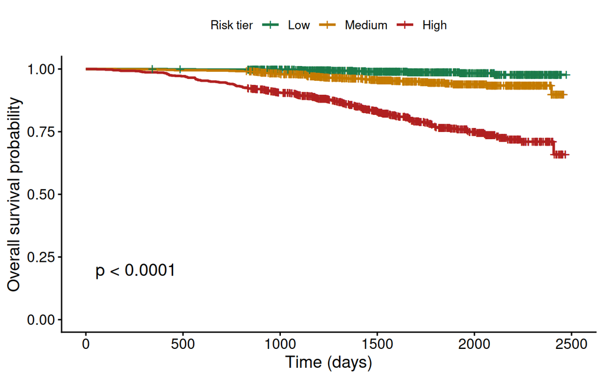

Figure 4. Kaplan-Meier overall survival curves for the three risk tiers (Low / Medium / High) defined by tertiles of the final Cox-Combined linear predictor on all 2,512 patients. The log-rank test gives p < 0.0001, and the observed mortality rates within each tier are 1.2 percent (Low), 4.9 percent (Medium), and 20.2 percent (High).

```r
km_tbl <- data.frame(
  time  = df_erpos_endo$ovrallSurvDays,
  event = df_erpos_endo$ovrallSurvEvent,
  tier  = tier3
)
km_fit <- survfit(Surv(time, event) ~ tier, data = km_tbl)
ggsurvplot(
  km_fit, data = km_tbl, pval = TRUE,
  legend.title = "Risk tier",
  legend.labs  = c("Low", "Medium", "High"),
  palette      = c("#1B7A4A", "#C47A00", "#B02020"),
  xlab         = "Time (days)",
  ylab         = "Overall survival probability",
  risk.table   = FALSE
)
```

## 5.4 Shiny Risk Calculator

The final Cox-Combined model, the 11-gene panel, and the tertile cut-points are loaded by a Shiny web application (full source in Appendix). Clinicians enter the six histopathological variables and upload a CSV of expression values for the 11 stability-selected genes; the application returns a percentile rank within the training cohort, an assigned risk tier with the corresponding group-level death rate, personalised 1-, 3-, and 5-year survival estimates from the fitted Cox model, and the top three drivers pushing the patient’s risk up and down (computed from the per-feature contribution to the linear predictor relative to the cohort mean). The interface is positioned as decision support for pathologist-to-oncologist reporting rather than as a standalone diagnostic.